# Optimal Treatment Analysis

## Outcome Variable

**Outcome Variable:** ever_wasted

## Predictor Variables

**Intervention Variable:** meducyrs

**Adjustment Set:**

- arm
- W_mage
- feducyrs
- W_mhtcm
- W_gagebrth
- W_birthwt
- W_birthlen
- single
- delta_W_mage
- delta_feducyrs
- delta_W_mhtcm
- delta_W_gagebrth
- delta_W_birthwt
- delta_W_birthlen
- delta_single

## Stratifying Variables

The analysis was stratified on these variable(s):

- agecat
- studyid
- country

## Data Summary

| agecat | studyid | country | meducyrs | ever_wasted | n_cell | n |
| --- | --- | --- | --- | --- | --- | --- |
| 0-24 months | ki0047075b-MAL-ED | BANGLADESH | High | 0 | 59 | 213 |
| 0-24 months | ki0047075b-MAL-ED | BANGLADESH | High | 1 | 19 | 213 |
| 0-24 months | ki0047075b-MAL-ED | BANGLADESH | Low | 0 | 46 | 213 |
| 0-24 months | ki0047075b-MAL-ED | BANGLADESH | Low | 1 | 24 | 213 |
| 0-24 months | ki0047075b-MAL-ED | BANGLADESH | Medium | 0 | 44 | 213 |
| 0-24 months | ki0047075b-MAL-ED | BANGLADESH | Medium | 1 | 21 | 213 |
| 0-24 months | ki0047075b-MAL-ED | BRAZIL | High | 0 | 76 | 232 |
| 0-24 months | ki0047075b-MAL-ED | BRAZIL | High | 1 | 3 | 232 |
| 0-24 months | ki0047075b-MAL-ED | BRAZIL | Low | 0 | 55 | 232 |
| 0-24 months | ki0047075b-MAL-ED | BRAZIL | Low | 1 | 8 | 232 |
| 0-24 months | ki0047075b-MAL-ED | BRAZIL | Medium | 0 | 82 | 232 |
| 0-24 months | ki0047075b-MAL-ED | BRAZIL | Medium | 1 | 8 | 232 |
| 0-24 months | ki0047075b-MAL-ED | INDIA | High | 0 | 39 | 220 |
| 0-24 months | ki0047075b-MAL-ED | INDIA | High | 1 | 24 | 220 |
| 0-24 months | ki0047075b-MAL-ED | INDIA | Low | 0 | 33 | 220 |
| 0-24 months | ki0047075b-MAL-ED | INDIA | Low | 1 | 43 | 220 |
| 0-24 months | ki0047075b-MAL-ED | INDIA | Medium | 0 | 44 | 220 |
| 0-24 months | ki0047075b-MAL-ED | INDIA | Medium | 1 | 37 | 220 |
| 0-24 months | ki0047075b-MAL-ED | NEPAL | High | 0 | 40 | 225 |
| 0-24 months | ki0047075b-MAL-ED | NEPAL | High | 1 | 13 | 225 |
| 0-24 months | ki0047075b-MAL-ED | NEPAL | Low | 0 | 69 | 225 |
| 0-24 months | ki0047075b-MAL-ED | NEPAL | Low | 1 | 27 | 225 |
| 0-24 months | ki0047075b-MAL-ED | NEPAL | Medium | 0 | 51 | 225 |
| 0-24 months | ki0047075b-MAL-ED | NEPAL | Medium | 1 | 25 | 225 |
| 0-24 months | ki0047075b-MAL-ED | PERU | High | 0 | 87 | 301 |
| 0-24 months | ki0047075b-MAL-ED | PERU | High | 1 | 3 | 301 |
| 0-24 months | ki0047075b-MAL-ED | PERU | Low | 0 | 93 | 301 |
| 0-24 months | ki0047075b-MAL-ED | PERU | Low | 1 | 11 | 301 |
| 0-24 months | ki0047075b-MAL-ED | PERU | Medium | 0 | 95 | 301 |
| 0-24 months | ki0047075b-MAL-ED | PERU | Medium | 1 | 12 | 301 |

[output cut: 438 more lines]

The following strata were considered:

- agecat: 0-24 months, studyid: ki0047075b-MAL-ED, country: BANGLADESH
- agecat: 0-24 months, studyid: ki0047075b-MAL-ED, country: BRAZIL
- agecat: 0-24 months, studyid: ki0047075b-MAL-ED, country: INDIA
- agecat: 0-24 months, studyid: ki0047075b-MAL-ED, country: NEPAL
- agecat: 0-24 months, studyid: ki0047075b-MAL-ED, country: PERU
- agecat: 0-24 months, studyid: ki0047075b-MAL-ED, country: SOUTH AFRICA
- agecat: 0-24 months, studyid: ki0047075b-MAL-ED, country: TANZANIA, UNITED REPUBLIC OF
- agecat: 0-24 months, studyid: ki1000108-CMC-V-BCS-2002, country: INDIA
- agecat: 0-24 months, studyid: ki1000108-IRC, country: INDIA
- agecat: 0-24 months, studyid: ki1000109-EE, country: PAKISTAN
- agecat: 0-24 months, studyid: ki1000304b-SAS-CompFeed, country: INDIA
- agecat: 0-24 months, studyid: ki1000304b-SAS-FoodSuppl, country: INDIA
- agecat: 0-24 months, studyid: ki1017093-NIH-Birth, country: BANGLADESH
- agecat: 0-24 months, studyid: ki1017093b-PROVIDE, country: BANGLADESH
- agecat: 0-24 months, studyid: ki1017093c-NIH-Crypto, country: BANGLADESH
- agecat: 0-24 months, studyid: ki1066203-TanzaniaChild2, country: TANZANIA, UNITED REPUBLIC OF
- agecat: 0-24 months, studyid: ki1112895-Guatemala BSC, country: GUATEMALA
- agecat: 0-24 months, studyid: ki1113344-GMS-Nepal, country: NEPAL
- agecat: 0-24 months, studyid: ki1119695-PROBIT, country: BELARUS
- agecat: 0-24 months, studyid: ki1126311-ZVITAMBO, country: ZIMBABWE
- agecat: 0-24 months, studyid: ki1135781-COHORTS, country: GUATEMALA
- agecat: 0-24 months, studyid: ki1135781-COHORTS, country: INDIA
- agecat: 0-24 months, studyid: ki1135781-COHORTS, country: PHILIPPINES
- agecat: 0-24 months, studyid: ki1148112-LCNI-5, country: MALAWI
- agecat: 0-24 months, studyid: kiGH5241-JiVitA-3, country: BANGLADESH
- agecat: 0-24 months, studyid: kiGH5241-JiVitA-4, country: BANGLADESH
- agecat: 0-6 months, studyid: ki0047075b-MAL-ED, country: BANGLADESH
- agecat: 0-6 months, studyid: ki0047075b-MAL-ED, country: BRAZIL
- agecat: 0-6 months, studyid: ki0047075b-MAL-ED, country: INDIA
- agecat: 0-6 months, studyid: ki0047075b-MAL-ED, country: NEPAL
- agecat: 0-6 months, studyid: ki0047075b-MAL-ED, country: PERU
- agecat: 0-6 months, studyid: ki0047075b-MAL-ED, country: SOUTH AFRICA
- agecat: 0-6 months, studyid: ki0047075b-MAL-ED, country: TANZANIA, UNITED REPUBLIC OF
- agecat: 0-6 months, studyid: ki1000108-CMC-V-BCS-2002, country: INDIA
- agecat: 0-6 months, studyid: ki1000108-IRC, country: INDIA
- agecat: 0-6 months, studyid: ki1000109-EE, country: PAKISTAN
- agecat: 0-6 months, studyid: ki1000304b-SAS-CompFeed, country: INDIA
- agecat: 0-6 months, studyid: ki1000304b-SAS-FoodSuppl, country: INDIA
- agecat: 0-6 months, studyid: ki1017093-NIH-Birth, country: BANGLADESH
- agecat: 0-6 months, studyid: ki1017093b-PROVIDE, country: BANGLADESH
- agecat: 0-6 months, studyid: ki1017093c-NIH-Crypto, country: BANGLADESH
- agecat: 0-6 months, studyid: ki1066203-TanzaniaChild2, country: TANZANIA, UNITED REPUBLIC OF
- agecat: 0-6 months, studyid: ki1112895-Guatemala BSC, country: GUATEMALA
- agecat: 0-6 months, studyid: ki1113344-GMS-Nepal, country: NEPAL
- agecat: 0-6 months, studyid: ki1119695-PROBIT, country: BELARUS
- agecat: 0-6 months, studyid: ki1126311-ZVITAMBO, country: ZIMBABWE
- agecat: 0-6 months, studyid: ki1135781-COHORTS, country: GUATEMALA
- agecat: 0-6 months, studyid: ki1135781-COHORTS, country: INDIA
- agecat: 0-6 months, studyid: ki1135781-COHORTS, country: PHILIPPINES
- agecat: 0-6 months, studyid: ki1148112-LCNI-5, country: MALAWI
- agecat: 0-6 months, studyid: kiGH5241-JiVitA-3, country: BANGLADESH
- agecat: 0-6 months, studyid: kiGH5241-JiVitA-4, country: BANGLADESH
- agecat: 6-24 months, studyid: ki0047075b-MAL-ED, country: BANGLADESH
- agecat: 6-24 months, studyid: ki0047075b-MAL-ED, country: BRAZIL
- agecat: 6-24 months, studyid: ki0047075b-MAL-ED, country: INDIA
- agecat: 6-24 months, studyid: ki0047075b-MAL-ED, country: NEPAL
- agecat: 6-24 months, studyid: ki0047075b-MAL-ED, country: PERU
- agecat: 6-24 months, studyid: ki0047075b-MAL-ED, country: SOUTH AFRICA
- agecat: 6-24 months, studyid: ki0047075b-MAL-ED, country: TANZANIA, UNITED REPUBLIC OF
- agecat: 6-24 months, studyid: ki1000108-CMC-V-BCS-2002, country: INDIA
- agecat: 6-24 months, studyid: ki1000108-IRC, country: INDIA
- agecat: 6-24 months, studyid: ki1000109-EE, country: PAKISTAN
- agecat: 6-24 months, studyid: ki1000304b-SAS-CompFeed, country: INDIA
- agecat: 6-24 months, studyid: ki1000304b-SAS-FoodSuppl, country: INDIA
- agecat: 6-24 months, studyid: ki1017093-NIH-Birth, country: BANGLADESH
- agecat: 6-24 months, studyid: ki1017093b-PROVIDE, country: BANGLADESH
- agecat: 6-24 months, studyid: ki1017093c-NIH-Crypto, country: BANGLADESH
- agecat: 6-24 months, studyid: ki1066203-TanzaniaChild2, country: TANZANIA, UNITED REPUBLIC OF
- agecat: 6-24 months, studyid: ki1112895-Guatemala BSC, country: GUATEMALA
- agecat: 6-24 months, studyid: ki1113344-GMS-Nepal, country: NEPAL
- agecat: 6-24 months, studyid: ki1119695-PROBIT, country: BELARUS
- agecat: 6-24 months, studyid: ki1126311-ZVITAMBO, country: ZIMBABWE
- agecat: 6-24 months, studyid: ki1135781-COHORTS, country: GUATEMALA
- agecat: 6-24 months, studyid: ki1135781-COHORTS, country: INDIA
- agecat: 6-24 months, studyid: ki1135781-COHORTS, country: PHILIPPINES
- agecat: 6-24 months, studyid: ki1148112-LCNI-5, country: MALAWI
- agecat: 6-24 months, studyid: kiGH5241-JiVitA-3, country: BANGLADESH
- agecat: 6-24 months, studyid: kiGH5241-JiVitA-4, country: BANGLADESH

### Dropped Strata

Some strata were dropped due to rare outcomes:

- agecat: 0-24 months, studyid: ki0047075b-MAL-ED, country: BRAZIL
- agecat: 0-24 months, studyid: ki0047075b-MAL-ED, country: PERU
- agecat: 0-24 months, studyid: ki0047075b-MAL-ED, country: TANZANIA, UNITED REPUBLIC OF
- agecat: 0-24 months, studyid: ki1000304b-SAS-FoodSuppl, country: INDIA
- agecat: 0-24 months, studyid: kiGH5241-JiVitA-4, country: BANGLADESH
- agecat: 0-6 months, studyid: ki0047075b-MAL-ED, country: BRAZIL
- agecat: 0-6 months, studyid: ki0047075b-MAL-ED, country: PERU
- agecat: 0-6 months, studyid: ki0047075b-MAL-ED, country: TANZANIA, UNITED REPUBLIC OF
- agecat: 0-6 months, studyid: ki1000109-EE, country: PAKISTAN
- agecat: 0-6 months, studyid: ki1000304b-SAS-FoodSuppl, country: INDIA
- agecat: 0-6 months, studyid: ki1112895-Guatemala BSC, country: GUATEMALA
- agecat: 0-6 months, studyid: ki1148112-LCNI-5, country: MALAWI
- agecat: 0-6 months, studyid: kiGH5241-JiVitA-4, country: BANGLADESH
- agecat: 6-24 months, studyid: ki0047075b-MAL-ED, country: BRAZIL
- agecat: 6-24 months, studyid: ki0047075b-MAL-ED, country: PERU
- agecat: 6-24 months, studyid: ki0047075b-MAL-ED, country: TANZANIA, UNITED REPUBLIC OF
- agecat: 6-24 months, studyid: ki1000109-EE, country: PAKISTAN
- agecat: 6-24 months, studyid: ki1000304b-SAS-FoodSuppl, country: INDIA
- agecat: 6-24 months, studyid: ki1112895-Guatemala BSC, country: GUATEMALA
- agecat: 6-24 months, studyid: kiGH5241-JiVitA-4, country: BANGLADESH

## Methods Detail

We’re interested in the causal parameters $E[Y_a]$ for all values of $a \in \mathcal{A}$. These parameters represent the mean outcome if, possibly contrary to fact, we intervened to set all units to have $A=a$. Under the randomization and positivity assumptions, these are identified by the statistical parameters $\psi_a=E_W[E_{Y|A,W}(Y|A=a,W)]$. In addition, we’re interested in the mean of $Y$, $E[Y]$ under no intervention (the observed mean). We will estimate these parameters by using SuperLearner to fit the relevant likelihood factors – $E_{Y|A,W}(Y|A=a,W)$ and $p(A=a|W)$, and then updating our likelihood fit using a joint TMLE.

For unadjusted analyses ($W=\{\}$), initial likelihoods were estimated using Lrnr_glm to estimate the simple $E(Y|A)$ and Lrnr_mean to estimate $p(A)$. For adjusted analyses, a small library containing Lrnr_glmnet, Lrnr_xgboost, and Lrnr_mean was used.

Having estimated these parameters, we will then use the delta method to estimate relative risks and attributable risks relative to a prespecified baseline level of $A$.

# Results Detail

## Results Plots

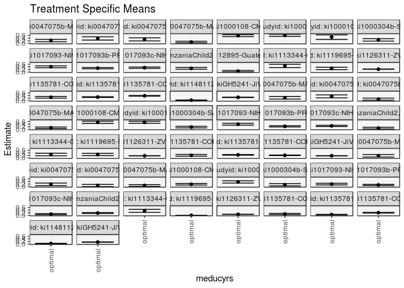

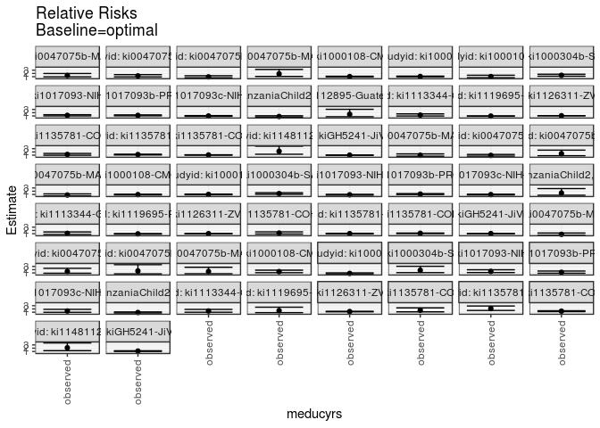

## Results Table

### Parameter: TSM

| agecat | studyid | country | intervention_level | baseline_level | estimate | ci_lower | ci_upper |
| --- | --- | --- | --- | --- | --- | --- | --- |
| 0-24 months | ki0047075b-MAL-ED | BANGLADESH | optimal | NA | 0.2186266 | 0.1274249 | 0.3098283 |
| 0-24 months | ki0047075b-MAL-ED | INDIA | optimal | NA | 0.3804739 | 0.2580110 | 0.5029368 |
| 0-24 months | ki0047075b-MAL-ED | NEPAL | optimal | NA | 0.3073766 | 0.1885139 | 0.4262394 |
| 0-24 months | ki0047075b-MAL-ED | SOUTH AFRICA | optimal | NA | 0.1047224 | 0.0414784 | 0.1679665 |
| 0-24 months | ki1000108-CMC-V-BCS-2002 | INDIA | optimal | NA | 0.5948265 | 0.5175561 | 0.6720969 |
| 0-24 months | ki1000108-IRC | INDIA | optimal | NA | 0.6196296 | 0.5392164 | 0.7000427 |
| 0-24 months | ki1000109-EE | PAKISTAN | optimal | NA | 0.4781324 | 0.3068122 | 0.6494526 |
| 0-24 months | ki1000304b-SAS-CompFeed | INDIA | optimal | NA | 0.2686345 | 0.1767796 | 0.3604894 |
| 0-24 months | ki1017093-NIH-Birth | BANGLADESH | optimal | NA | 0.4031537 | 0.3296588 | 0.4766486 |
| 0-24 months | ki1017093b-PROVIDE | BANGLADESH | optimal | NA | 0.3006999 | 0.2516365 | 0.3497633 |
| 0-24 months | ki1017093c-NIH-Crypto | BANGLADESH | optimal | NA | 0.3366585 | 0.2847066 | 0.3886104 |
| 0-24 months | ki1066203-TanzaniaChild2 | TANZANIA, UNITED REPUBLIC OF | optimal | NA | 0.2857741 | 0.2168233 | 0.3547249 |
| 0-24 months | ki1112895-Guatemala BSC | GUATEMALA | optimal | NA | 0.0698031 | 0.0157652 | 0.1238410 |
| 0-24 months | ki1113344-GMS-Nepal | NEPAL | optimal | NA | 0.4680930 | 0.3438201 | 0.5923659 |
| 0-24 months | ki1119695-PROBIT | BELARUS | optimal | NA | 0.2768834 | 0.1846046 | 0.3691621 |
| 0-24 months | ki1126311-ZVITAMBO | ZIMBABWE | optimal | NA | 0.2203516 | 0.2120212 | 0.2286821 |
| 0-24 months | ki1135781-COHORTS | GUATEMALA | optimal | NA | 0.2633407 | 0.1973413 | 0.3293400 |
| 0-24 months | ki1135781-COHORTS | INDIA | optimal | NA | 0.2788869 | 0.2501747 | 0.3075991 |
| 0-24 months | ki1135781-COHORTS | PHILIPPINES | optimal | NA | 0.3772926 | 0.3512318 | 0.4033534 |
| 0-24 months | ki1148112-LCNI-5 | MALAWI | optimal | NA | 0.0361408 | 0.0149020 | 0.0573796 |
| 0-24 months | kiGH5241-JiVitA-3 | BANGLADESH | optimal | NA | 0.2592535 | 0.2447799 | 0.2737270 |
| 0-6 months | ki0047075b-MAL-ED | BANGLADESH | optimal | NA | 0.2254818 | 0.1256172 | 0.3253463 |
| 0-6 months | ki0047075b-MAL-ED | INDIA | optimal | NA | 0.3342692 | 0.2206862 | 0.4478523 |
| 0-6 months | ki0047075b-MAL-ED | NEPAL | optimal | NA | 0.1216956 | 0.0428155 | 0.2005756 |
| 0-6 months | ki0047075b-MAL-ED | SOUTH AFRICA | optimal | NA | 0.1246543 | 0.0642307 | 0.1850779 |
| 0-6 months | ki1000108-CMC-V-BCS-2002 | INDIA | optimal | NA | 0.5427392 | 0.4604346 | 0.6250437 |
| 0-6 months | ki1000108-IRC | INDIA | optimal | NA | 0.5418911 | 0.4654355 | 0.6183466 |
| 0-6 months | ki1000304b-SAS-CompFeed | INDIA | optimal | NA | 0.1753931 | 0.1138125 | 0.2369737 |
| 0-6 months | ki1017093-NIH-Birth | BANGLADESH | optimal | NA | 0.3956161 | 0.3238843 | 0.4673479 |
| 0-6 months | ki1017093b-PROVIDE | BANGLADESH | optimal | NA | 0.2338325 | 0.1897611 | 0.2779039 |
| 0-6 months | ki1017093c-NIH-Crypto | BANGLADESH | optimal | NA | 0.2694927 | 0.2227024 | 0.3162830 |
| 0-6 months | ki1066203-TanzaniaChild2 | TANZANIA, UNITED REPUBLIC OF | optimal | NA | 0.0967679 | 0.0318019 | 0.1617339 |
| 0-6 months | ki1113344-GMS-Nepal | NEPAL | optimal | NA | 0.2707112 | 0.1738667 | 0.3675556 |
| 0-6 months | ki1119695-PROBIT | BELARUS | optimal | NA | 0.2734852 | 0.1848341 | 0.3621363 |
| 0-6 months | ki1126311-ZVITAMBO | ZIMBABWE | optimal | NA | 0.1772536 | 0.1695352 | 0.1849719 |
| 0-6 months | ki1135781-COHORTS | GUATEMALA | optimal | NA | 0.2109030 | 0.1443578 | 0.2774481 |
| 0-6 months | ki1135781-COHORTS | INDIA | optimal | NA | 0.2447482 | 0.2204736 | 0.2690227 |
| 0-6 months | ki1135781-COHORTS | PHILIPPINES | optimal | NA | 0.2113131 | 0.1907495 | 0.2318767 |
| 0-6 months | kiGH5241-JiVitA-3 | BANGLADESH | optimal | NA | 0.1760450 | 0.1650624 | 0.1870275 |
| 6-24 months | ki0047075b-MAL-ED | BANGLADESH | optimal | NA | 0.1739072 | 0.0791032 | 0.2687112 |
| 6-24 months | ki0047075b-MAL-ED | INDIA | optimal | NA | 0.1799882 | 0.0797716 | 0.2802048 |
| 6-24 months | ki0047075b-MAL-ED | NEPAL | optimal | NA | 0.0961150 | 0.0137239 | 0.1785062 |
| 6-24 months | ki0047075b-MAL-ED | SOUTH AFRICA | optimal | NA | 0.0956884 | 0.0274342 | 0.1639427 |
| 6-24 months | ki1000108-CMC-V-BCS-2002 | INDIA | optimal | NA | 0.1881860 | 0.1260401 | 0.2503318 |
| 6-24 months | ki1000108-IRC | INDIA | optimal | NA | 0.3644570 | 0.2787379 | 0.4501760 |
| 6-24 months | ki1000304b-SAS-CompFeed | INDIA | optimal | NA | 0.1484213 | 0.0647326 | 0.2321100 |
| 6-24 months | ki1017093-NIH-Birth | BANGLADESH | optimal | NA | 0.1987911 | 0.1342944 | 0.2632878 |
| 6-24 months | ki1017093b-PROVIDE | BANGLADESH | optimal | NA | 0.1348069 | 0.0884970 | 0.1811169 |
| 6-24 months | ki1017093c-NIH-Crypto | BANGLADESH | optimal | NA | 0.0968835 | 0.0599965 | 0.1337705 |
| 6-24 months | ki1066203-TanzaniaChild2 | TANZANIA, UNITED REPUBLIC OF | optimal | NA | 0.1778688 | 0.1430386 | 0.2126990 |
| 6-24 months | ki1113344-GMS-Nepal | NEPAL | optimal | NA | 0.3473052 | 0.2322507 | 0.4623596 |
| 6-24 months | ki1119695-PROBIT | BELARUS | optimal | NA | 0.0056077 | 0.0020797 | 0.0091357 |
| 6-24 months | ki1126311-ZVITAMBO | ZIMBABWE | optimal | NA | 0.0787351 | 0.0714288 | 0.0860413 |
| 6-24 months | ki1135781-COHORTS | GUATEMALA | optimal | NA | 0.1083277 | 0.0640117 | 0.1526437 |
| 6-24 months | ki1135781-COHORTS | INDIA | optimal | NA | 0.0598811 | 0.0405167 | 0.0792455 |
| 6-24 months | ki1135781-COHORTS | PHILIPPINES | optimal | NA | 0.2039587 | 0.1794005 | 0.2285168 |
| 6-24 months | ki1148112-LCNI-5 | MALAWI | optimal | NA | 0.0364660 | 0.0149355 | 0.0579965 |
| 6-24 months | kiGH5241-JiVitA-3 | BANGLADESH | optimal | NA | 0.1485759 | 0.1344149 | 0.1627369 |

### Parameter: E(Y)

| agecat | studyid | country | intervention_level | baseline_level | estimate | ci_lower | ci_upper |
| --- | --- | --- | --- | --- | --- | --- | --- |
| 0-24 months | ki0047075b-MAL-ED | BANGLADESH | observed | NA | 0.3004695 | 0.2387555 | 0.3621835 |
| 0-24 months | ki0047075b-MAL-ED | INDIA | observed | NA | 0.4727273 | 0.4066048 | 0.5388497 |
| 0-24 months | ki0047075b-MAL-ED | NEPAL | observed | NA | 0.2888889 | 0.2295338 | 0.3482440 |
| 0-24 months | ki0047075b-MAL-ED | SOUTH AFRICA | observed | NA | 0.1955128 | 0.1514355 | 0.2395901 |
| 0-24 months | ki1000108-CMC-V-BCS-2002 | INDIA | observed | NA | 0.6139410 | 0.5644682 | 0.6634139 |
| 0-24 months | ki1000108-IRC | INDIA | observed | NA | 0.6560976 | 0.6100625 | 0.7021326 |
| 0-24 months | ki1000109-EE | PAKISTAN | observed | NA | 0.4907162 | 0.4401862 | 0.5412462 |
| 0-24 months | ki1000304b-SAS-CompFeed | INDIA | observed | NA | 0.3822894 | 0.3008363 | 0.4637425 |
| 0-24 months | ki1017093-NIH-Birth | BANGLADESH | observed | NA | 0.4775641 | 0.4383415 | 0.5167867 |
| 0-24 months | ki1017093b-PROVIDE | BANGLADESH | observed | NA | 0.3514286 | 0.3160364 | 0.3868207 |
| 0-24 months | ki1017093c-NIH-Crypto | BANGLADESH | observed | NA | 0.3311346 | 0.2976093 | 0.3646598 |
| 0-24 months | ki1066203-TanzaniaChild2 | TANZANIA, UNITED REPUBLIC OF | observed | NA | 0.2367980 | 0.2197367 | 0.2538593 |
| 0-24 months | ki1112895-Guatemala BSC | GUATEMALA | observed | NA | 0.1063830 | 0.0703329 | 0.1424331 |
| 0-24 months | ki1113344-GMS-Nepal | NEPAL | observed | NA | 0.5909850 | 0.5515796 | 0.6303903 |
| 0-24 months | ki1119695-PROBIT | BELARUS | observed | NA | 0.2655346 | 0.1719990 | 0.3590703 |
| 0-24 months | ki1126311-ZVITAMBO | ZIMBABWE | observed | NA | 0.2346433 | 0.2276029 | 0.2416837 |
| 0-24 months | ki1135781-COHORTS | GUATEMALA | observed | NA | 0.3235294 | 0.2874259 | 0.3596329 |
| 0-24 months | ki1135781-COHORTS | INDIA | observed | NA | 0.3329911 | 0.3209071 | 0.3450751 |
| 0-24 months | ki1135781-COHORTS | PHILIPPINES | observed | NA | 0.4036125 | 0.3861835 | 0.4210415 |
| 0-24 months | ki1148112-LCNI-5 | MALAWI | observed | NA | 0.0798526 | 0.0612199 | 0.0984853 |
| 0-24 months | kiGH5241-JiVitA-3 | BANGLADESH | observed | NA | 0.2642771 | 0.2551890 | 0.2733653 |
| 0-6 months | ki0047075b-MAL-ED | BANGLADESH | observed | NA | 0.2206573 | 0.1648355 | 0.2764790 |
| 0-6 months | ki0047075b-MAL-ED | INDIA | observed | NA | 0.3136364 | 0.2521871 | 0.3750856 |
| 0-6 months | ki0047075b-MAL-ED | NEPAL | observed | NA | 0.1777778 | 0.1277101 | 0.2278455 |
| 0-6 months | ki0047075b-MAL-ED | SOUTH AFRICA | observed | NA | 0.1025641 | 0.0688457 | 0.1362825 |
| 0-6 months | ki1000108-CMC-V-BCS-2002 | INDIA | observed | NA | 0.5190217 | 0.4679041 | 0.5701394 |
| 0-6 months | ki1000108-IRC | INDIA | observed | NA | 0.5439024 | 0.4956326 | 0.5921723 |
| 0-6 months | ki1000304b-SAS-CompFeed | INDIA | observed | NA | 0.2207792 | 0.1636864 | 0.2778721 |
| 0-6 months | ki1017093-NIH-Birth | BANGLADESH | observed | NA | 0.3569132 | 0.3192325 | 0.3945938 |
| 0-6 months | ki1017093b-PROVIDE | BANGLADESH | observed | NA | 0.2585714 | 0.2261125 | 0.2910304 |
| 0-6 months | ki1017093c-NIH-Crypto | BANGLADESH | observed | NA | 0.2585752 | 0.2273844 | 0.2897660 |
| 0-6 months | ki1066203-TanzaniaChild2 | TANZANIA, UNITED REPUBLIC OF | observed | NA | 0.1395641 | 0.1256566 | 0.1534717 |
| 0-6 months | ki1113344-GMS-Nepal | NEPAL | observed | NA | 0.2954925 | 0.2589234 | 0.3320615 |
| 0-6 months | ki1119695-PROBIT | BELARUS | observed | NA | 0.2599065 | 0.1654090 | 0.3544039 |
| 0-6 months | ki1126311-ZVITAMBO | ZIMBABWE | observed | NA | 0.1809503 | 0.1745333 | 0.1873674 |
| 0-6 months | ki1135781-COHORTS | GUATEMALA | observed | NA | 0.2500000 | 0.2121588 | 0.2878412 |
| 0-6 months | ki1135781-COHORTS | INDIA | observed | NA | 0.2511554 | 0.2398221 | 0.2624886 |
| 0-6 months | ki1135781-COHORTS | PHILIPPINES | observed | NA | 0.2355453 | 0.2204685 | 0.2506222 |
| 0-6 months | kiGH5241-JiVitA-3 | BANGLADESH | observed | NA | 0.1822913 | 0.1742792 | 0.1903033 |
| 6-24 months | ki0047075b-MAL-ED | BANGLADESH | observed | NA | 0.1384615 | 0.0898601 | 0.1870630 |
| 6-24 months | ki0047075b-MAL-ED | INDIA | observed | NA | 0.2657005 | 0.2053824 | 0.3260185 |
| 6-24 months | ki0047075b-MAL-ED | NEPAL | observed | NA | 0.1545455 | 0.1066715 | 0.2024194 |
| 6-24 months | ki0047075b-MAL-ED | SOUTH AFRICA | observed | NA | 0.1389961 | 0.0967835 | 0.1812087 |
| 6-24 months | ki1000108-CMC-V-BCS-2002 | INDIA | observed | NA | 0.2654155 | 0.2205451 | 0.3102860 |
| 6-24 months | ki1000108-IRC | INDIA | observed | NA | 0.3097561 | 0.2649438 | 0.3545684 |
| 6-24 months | ki1000304b-SAS-CompFeed | INDIA | observed | NA | 0.2708333 | 0.2169112 | 0.3247555 |
| 6-24 months | ki1017093-NIH-Birth | BANGLADESH | observed | NA | 0.2939002 | 0.2554778 | 0.3323226 |
| 6-24 months | ki1017093b-PROVIDE | BANGLADESH | observed | NA | 0.1609756 | 0.1319065 | 0.1900447 |
| 6-24 months | ki1017093c-NIH-Crypto | BANGLADESH | observed | NA | 0.1315069 | 0.1069744 | 0.1560393 |
| 6-24 months | ki1066203-TanzaniaChild2 | TANZANIA, UNITED REPUBLIC OF | observed | NA | 0.1606166 | 0.1445647 | 0.1766685 |
| 6-24 months | ki1113344-GMS-Nepal | NEPAL | observed | NA | 0.4735945 | 0.4331684 | 0.5140207 |
| 6-24 months | ki1119695-PROBIT | BELARUS | observed | NA | 0.0082759 | 0.0065972 | 0.0099545 |
| 6-24 months | ki1126311-ZVITAMBO | ZIMBABWE | observed | NA | 0.0940163 | 0.0884807 | 0.0995519 |
| 6-24 months | ki1135781-COHORTS | GUATEMALA | observed | NA | 0.1737649 | 0.1430865 | 0.2044433 |
| 6-24 months | ki1135781-COHORTS | INDIA | observed | NA | 0.1266654 | 0.1178579 | 0.1354730 |
| 6-24 months | ki1135781-COHORTS | PHILIPPINES | observed | NA | 0.2666429 | 0.2502871 | 0.2829988 |
| 6-24 months | ki1148112-LCNI-5 | MALAWI | observed | NA | 0.0772105 | 0.0587369 | 0.0956840 |
| 6-24 months | kiGH5241-JiVitA-3 | BANGLADESH | observed | NA | 0.1649110 | 0.1557149 | 0.1741072 |

### Parameter: RR

| agecat | studyid | country | intervention_level | baseline_level | estimate | ci_lower | ci_upper |
| --- | --- | --- | --- | --- | --- | --- | --- |
| 0-24 months | ki0047075b-MAL-ED | BANGLADESH | observed | optimal | 1.3743503 | 0.9554278 | 1.976956 |
| 0-24 months | ki0047075b-MAL-ED | INDIA | observed | optimal | 1.2424697 | 0.9424356 | 1.638023 |
| 0-24 months | ki0047075b-MAL-ED | NEPAL | observed | optimal | 0.9398531 | 0.6750692 | 1.308494 |
| 0-24 months | ki0047075b-MAL-ED | SOUTH AFRICA | observed | optimal | 1.8669624 | 1.0788531 | 3.230790 |
| 0-24 months | ki1000108-CMC-V-BCS-2002 | INDIA | observed | optimal | 1.0321346 | 0.9337993 | 1.140825 |
| 0-24 months | ki1000108-IRC | INDIA | observed | optimal | 1.0588545 | 0.9562447 | 1.172475 |
| 0-24 months | ki1000109-EE | PAKISTAN | observed | optimal | 1.0263186 | 0.7244209 | 1.454030 |
| 0-24 months | ki1000304b-SAS-CompFeed | INDIA | observed | optimal | 1.4230841 | 1.1522734 | 1.757542 |
| 0-24 months | ki1017093-NIH-Birth | BANGLADESH | observed | optimal | 1.1845708 | 1.0125748 | 1.385782 |
| 0-24 months | ki1017093b-PROVIDE | BANGLADESH | observed | optimal | 1.1687021 | 1.0346500 | 1.320122 |
| 0-24 months | ki1017093c-NIH-Crypto | BANGLADESH | observed | optimal | 0.9835920 | 0.8765710 | 1.103679 |
| 0-24 months | ki1066203-TanzaniaChild2 | TANZANIA, UNITED REPUBLIC OF | observed | optimal | 0.8286195 | 0.6567075 | 1.045534 |
| 0-24 months | ki1112895-Guatemala BSC | GUATEMALA | observed | optimal | 1.5240440 | 0.7647745 | 3.037118 |
| 0-24 months | ki1113344-GMS-Nepal | NEPAL | observed | optimal | 1.2625375 | 0.9798471 | 1.626786 |
| 0-24 months | ki1119695-PROBIT | BELARUS | observed | optimal | 0.9590125 | 0.9107660 | 1.009815 |
| 0-24 months | ki1126311-ZVITAMBO | ZIMBABWE | observed | optimal | 1.0648584 | 1.0408646 | 1.089405 |
| 0-24 months | ki1135781-COHORTS | GUATEMALA | observed | optimal | 1.2285585 | 0.9838221 | 1.534176 |
| 0-24 months | ki1135781-COHORTS | INDIA | observed | optimal | 1.1940004 | 1.0850115 | 1.313937 |
| 0-24 months | ki1135781-COHORTS | PHILIPPINES | observed | optimal | 1.0697598 | 1.0146146 | 1.127902 |
| 0-24 months | ki1148112-LCNI-5 | MALAWI | observed | optimal | 2.2094862 | 1.2960423 | 3.766721 |
| 0-24 months | kiGH5241-JiVitA-3 | BANGLADESH | observed | optimal | 1.0193774 | 0.9756815 | 1.065030 |
| 0-6 months | ki0047075b-MAL-ED | BANGLADESH | observed | optimal | 0.9786036 | 0.6860723 | 1.395866 |
| 0-6 months | ki0047075b-MAL-ED | INDIA | observed | optimal | 0.9382747 | 0.7106514 | 1.238806 |
| 0-6 months | ki0047075b-MAL-ED | NEPAL | observed | optimal | 1.4608400 | 0.8363518 | 2.551622 |
| 0-6 months | ki0047075b-MAL-ED | SOUTH AFRICA | observed | optimal | 0.8227882 | 0.5777100 | 1.171834 |
| 0-6 months | ki1000108-CMC-V-BCS-2002 | INDIA | observed | optimal | 0.9563005 | 0.8487219 | 1.077515 |
| 0-6 months | ki1000108-IRC | INDIA | observed | optimal | 1.0037117 | 0.8974637 | 1.122538 |
| 0-6 months | ki1000304b-SAS-CompFeed | INDIA | observed | optimal | 1.2587682 | 1.0400332 | 1.523507 |
| 0-6 months | ki1017093-NIH-Birth | BANGLADESH | observed | optimal | 0.9021705 | 0.7786168 | 1.045330 |
| 0-6 months | ki1017093b-PROVIDE | BANGLADESH | observed | optimal | 1.1057975 | 0.9750117 | 1.254127 |
| 0-6 months | ki1017093c-NIH-Crypto | BANGLADESH | observed | optimal | 0.9594886 | 0.8472966 | 1.086536 |
| 0-6 months | ki1066203-TanzaniaChild2 | TANZANIA, UNITED REPUBLIC OF | observed | optimal | 1.4422564 | 0.7432728 | 2.798573 |
| 0-6 months | ki1113344-GMS-Nepal | NEPAL | observed | optimal | 1.0915414 | 0.7765686 | 1.534266 |
| 0-6 months | ki1119695-PROBIT | BELARUS | observed | optimal | 0.9503494 | 0.8799674 | 1.026361 |
| 0-6 months | ki1126311-ZVITAMBO | ZIMBABWE | observed | optimal | 1.0208557 | 0.9955854 | 1.046767 |
| 0-6 months | ki1135781-COHORTS | GUATEMALA | observed | optimal | 1.1853792 | 0.8989754 | 1.563028 |
| 0-6 months | ki1135781-COHORTS | INDIA | observed | optimal | 1.0261787 | 0.9392679 | 1.121131 |
| 0-6 months | ki1135781-COHORTS | PHILIPPINES | observed | optimal | 1.1146747 | 1.0354673 | 1.199941 |
| 0-6 months | kiGH5241-JiVitA-3 | BANGLADESH | observed | optimal | 1.0354814 | 0.9866125 | 1.086771 |
| 6-24 months | ki0047075b-MAL-ED | BANGLADESH | observed | optimal | 0.7961805 | 0.5267620 | 1.203396 |
| 6-24 months | ki0047075b-MAL-ED | INDIA | observed | optimal | 1.4762106 | 0.8986570 | 2.424949 |
| 6-24 months | ki0047075b-MAL-ED | NEPAL | observed | optimal | 1.6079220 | 0.7313338 | 3.535203 |
| 6-24 months | ki0047075b-MAL-ED | SOUTH AFRICA | observed | optimal | 1.4525907 | 0.7681471 | 2.746895 |
| 6-24 months | ki1000108-CMC-V-BCS-2002 | INDIA | observed | optimal | 1.4103898 | 1.0736781 | 1.852696 |
| 6-24 months | ki1000108-IRC | INDIA | observed | optimal | 0.8499113 | 0.7081974 | 1.019983 |
| 6-24 months | ki1000304b-SAS-CompFeed | INDIA | observed | optimal | 1.8247608 | 1.0936652 | 3.044581 |
| 6-24 months | ki1017093-NIH-Birth | BANGLADESH | observed | optimal | 1.4784375 | 1.1058863 | 1.976494 |
| 6-24 months | ki1017093b-PROVIDE | BANGLADESH | observed | optimal | 1.1941196 | 0.9007014 | 1.583123 |
| 6-24 months | ki1017093c-NIH-Crypto | BANGLADESH | observed | optimal | 1.3573709 | 0.9763021 | 1.887178 |
| 6-24 months | ki1066203-TanzaniaChild2 | TANZANIA, UNITED REPUBLIC OF | observed | optimal | 0.9030062 | 0.7620875 | 1.069983 |
| 6-24 months | ki1113344-GMS-Nepal | NEPAL | observed | optimal | 1.3636266 | 0.9940830 | 1.870545 |
| 6-24 months | ki1119695-PROBIT | BELARUS | observed | optimal | 1.4758027 | 0.8588119 | 2.536054 |
| 6-24 months | ki1126311-ZVITAMBO | ZIMBABWE | observed | optimal | 1.1940842 | 1.1114469 | 1.282866 |
| 6-24 months | ki1135781-COHORTS | GUATEMALA | observed | optimal | 1.6040669 | 1.1052823 | 2.327940 |
| 6-24 months | ki1135781-COHORTS | INDIA | observed | optimal | 2.1152818 | 1.5419240 | 2.901840 |
| 6-24 months | ki1135781-COHORTS | PHILIPPINES | observed | optimal | 1.3073381 | 1.1816637 | 1.446378 |
| 6-24 months | ki1148112-LCNI-5 | MALAWI | observed | optimal | 2.1173283 | 1.2420075 | 3.609543 |
| 6-24 months | kiGH5241-JiVitA-3 | BANGLADESH | observed | optimal | 1.1099449 | 1.0239120 | 1.203207 |

### Parameter: PAR

| agecat | studyid | country | intervention_level | baseline_level | estimate | ci_lower | ci_upper |
| --- | --- | --- | --- | --- | --- | --- | --- |
| 0-24 months | ki0047075b-MAL-ED | BANGLADESH | optimal | NA | 0.0818429 | 0.0005583 | 0.1631275 |
| 0-24 months | ki0047075b-MAL-ED | INDIA | optimal | NA | 0.0922534 | -0.0124202 | 0.1969269 |
| 0-24 months | ki0047075b-MAL-ED | NEPAL | optimal | NA | -0.0184877 | -0.1202114 | 0.0832359 |
| 0-24 months | ki0047075b-MAL-ED | SOUTH AFRICA | optimal | NA | 0.0907904 | 0.0308538 | 0.1507270 |
| 0-24 months | ki1000108-CMC-V-BCS-2002 | INDIA | optimal | NA | 0.0191145 | -0.0404271 | 0.0786560 |
| 0-24 months | ki1000108-IRC | INDIA | optimal | NA | 0.0364680 | -0.0264682 | 0.0994042 |
| 0-24 months | ki1000109-EE | PAKISTAN | optimal | NA | 0.0125838 | -0.1540484 | 0.1792160 |
| 0-24 months | ki1000304b-SAS-CompFeed | INDIA | optimal | NA | 0.1136550 | 0.0590766 | 0.1682333 |
| 0-24 months | ki1017093-NIH-Birth | BANGLADESH | optimal | NA | 0.0744104 | 0.0113116 | 0.1375092 |
| 0-24 months | ki1017093b-PROVIDE | BANGLADESH | optimal | NA | 0.0507287 | 0.0140789 | 0.0873785 |
| 0-24 months | ki1017093c-NIH-Crypto | BANGLADESH | optimal | NA | -0.0055239 | -0.0443158 | 0.0332680 |
| 0-24 months | ki1066203-TanzaniaChild2 | TANZANIA, UNITED REPUBLIC OF | optimal | NA | -0.0489761 | -0.1154088 | 0.0174566 |
| 0-24 months | ki1112895-Guatemala BSC | GUATEMALA | optimal | NA | 0.0365799 | -0.0128910 | 0.0860508 |
| 0-24 months | ki1113344-GMS-Nepal | NEPAL | optimal | NA | 0.1228920 | 0.0043884 | 0.2413956 |
| 0-24 months | ki1119695-PROBIT | BELARUS | optimal | NA | -0.0113488 | -0.0244253 | 0.0017278 |
| 0-24 months | ki1126311-ZVITAMBO | ZIMBABWE | optimal | NA | 0.0142916 | 0.0092545 | 0.0193288 |
| 0-24 months | ki1135781-COHORTS | GUATEMALA | optimal | NA | 0.0601888 | 0.0014387 | 0.1189388 |
| 0-24 months | ki1135781-COHORTS | INDIA | optimal | NA | 0.0541042 | 0.0273713 | 0.0808371 |
| 0-24 months | ki1135781-COHORTS | PHILIPPINES | optimal | NA | 0.0263199 | 0.0063454 | 0.0462944 |
| 0-24 months | ki1148112-LCNI-5 | MALAWI | optimal | NA | 0.0437118 | 0.0221318 | 0.0652917 |
| 0-24 months | kiGH5241-JiVitA-3 | BANGLADESH | optimal | NA | 0.0050237 | -0.0063350 | 0.0163823 |
| 0-6 months | ki0047075b-MAL-ED | BANGLADESH | optimal | NA | -0.0048245 | -0.0849531 | 0.0753042 |
| 0-6 months | ki0047075b-MAL-ED | INDIA | optimal | NA | -0.0206329 | -0.1135962 | 0.0723305 |
| 0-6 months | ki0047075b-MAL-ED | NEPAL | optimal | NA | 0.0560822 | -0.0121299 | 0.1242943 |
| 0-6 months | ki0047075b-MAL-ED | SOUTH AFRICA | optimal | NA | -0.0220902 | -0.0668219 | 0.0226415 |
| 0-6 months | ki1000108-CMC-V-BCS-2002 | INDIA | optimal | NA | -0.0237174 | -0.0884364 | 0.0410015 |
| 0-6 months | ki1000108-IRC | INDIA | optimal | NA | 0.0020113 | -0.0586241 | 0.0626468 |
| 0-6 months | ki1000304b-SAS-CompFeed | INDIA | optimal | NA | 0.0453861 | 0.0122246 | 0.0785477 |
| 0-6 months | ki1017093-NIH-Birth | BANGLADESH | optimal | NA | -0.0387029 | -0.0971190 | 0.0197132 |
| 0-6 months | ki1017093b-PROVIDE | BANGLADESH | optimal | NA | 0.0247389 | -0.0044720 | 0.0539497 |
| 0-6 months | ki1017093c-NIH-Crypto | BANGLADESH | optimal | NA | -0.0109175 | -0.0444605 | 0.0226254 |
| 0-6 months | ki1066203-TanzaniaChild2 | TANZANIA, UNITED REPUBLIC OF | optimal | NA | 0.0427962 | -0.0214493 | 0.1070417 |
| 0-6 months | ki1113344-GMS-Nepal | NEPAL | optimal | NA | 0.0247813 | -0.0675545 | 0.1171171 |
| 0-6 months | ki1119695-PROBIT | BELARUS | optimal | NA | -0.0135787 | -0.0321396 | 0.0049822 |
| 0-6 months | ki1126311-ZVITAMBO | ZIMBABWE | optimal | NA | 0.0036967 | -0.0007474 | 0.0081409 |
| 0-6 months | ki1135781-COHORTS | GUATEMALA | optimal | NA | 0.0390970 | -0.0195191 | 0.0977132 |
| 0-6 months | ki1135781-COHORTS | INDIA | optimal | NA | 0.0064072 | -0.0152552 | 0.0280696 |
| 0-6 months | ki1135781-COHORTS | PHILIPPINES | optimal | NA | 0.0242323 | 0.0085695 | 0.0398950 |
| 0-6 months | kiGH5241-JiVitA-3 | BANGLADESH | optimal | NA | 0.0062463 | -0.0022932 | 0.0147858 |
| 6-24 months | ki0047075b-MAL-ED | BANGLADESH | optimal | NA | -0.0354457 | -0.1084932 | 0.0376018 |
| 6-24 months | ki0047075b-MAL-ED | INDIA | optimal | NA | 0.0857123 | -0.0046862 | 0.1761108 |
| 6-24 months | ki0047075b-MAL-ED | NEPAL | optimal | NA | 0.0584304 | -0.0187663 | 0.1356271 |
| 6-24 months | ki0047075b-MAL-ED | SOUTH AFRICA | optimal | NA | 0.0433077 | -0.0187058 | 0.1053212 |
| 6-24 months | ki1000108-CMC-V-BCS-2002 | INDIA | optimal | NA | 0.0772296 | 0.0251019 | 0.1293573 |
| 6-24 months | ki1000108-IRC | INDIA | optimal | NA | -0.0547009 | -0.1218163 | 0.0124146 |
| 6-24 months | ki1000304b-SAS-CompFeed | INDIA | optimal | NA | 0.1224121 | 0.0444908 | 0.2003333 |
| 6-24 months | ki1017093-NIH-Birth | BANGLADESH | optimal | NA | 0.0951091 | 0.0366923 | 0.1535259 |
| 6-24 months | ki1017093b-PROVIDE | BANGLADESH | optimal | NA | 0.0261687 | -0.0118663 | 0.0642037 |
| 6-24 months | ki1017093c-NIH-Crypto | BANGLADESH | optimal | NA | 0.0346233 | 0.0021310 | 0.0671156 |
| 6-24 months | ki1066203-TanzaniaChild2 | TANZANIA, UNITED REPUBLIC OF | optimal | NA | -0.0172522 | -0.0474582 | 0.0129539 |
| 6-24 months | ki1113344-GMS-Nepal | NEPAL | optimal | NA | 0.1262894 | 0.0164926 | 0.2360862 |
| 6-24 months | ki1119695-PROBIT | BELARUS | optimal | NA | 0.0026682 | -0.0002626 | 0.0055990 |
| 6-24 months | ki1126311-ZVITAMBO | ZIMBABWE | optimal | NA | 0.0152812 | 0.0095635 | 0.0209990 |
| 6-24 months | ki1135781-COHORTS | GUATEMALA | optimal | NA | 0.0654372 | 0.0232571 | 0.1076173 |
| 6-24 months | ki1135781-COHORTS | INDIA | optimal | NA | 0.0667843 | 0.0472692 | 0.0862995 |
| 6-24 months | ki1135781-COHORTS | PHILIPPINES | optimal | NA | 0.0626843 | 0.0418739 | 0.0834946 |
| 6-24 months | ki1148112-LCNI-5 | MALAWI | optimal | NA | 0.0407445 | 0.0192203 | 0.0622686 |
| 6-24 months | kiGH5241-JiVitA-3 | BANGLADESH | optimal | NA | 0.0163352 | 0.0042597 | 0.0284106 |

### Parameter: PAF

| agecat | studyid | country | intervention_level | baseline_level | estimate | ci_lower | ci_upper |
| --- | --- | --- | --- | --- | --- | --- | --- |
| 0-24 months | ki0047075b-MAL-ED | BANGLADESH | optimal | NA | 0.2723835 | -0.0466516 | 0.4941719 |
| 0-24 months | ki0047075b-MAL-ED | INDIA | optimal | NA | 0.1951514 | -0.0610805 | 0.3895078 |
| 0-24 months | ki0047075b-MAL-ED | NEPAL | optimal | NA | -0.0639960 | -0.4813296 | 0.2357625 |
| 0-24 months | ki0047075b-MAL-ED | SOUTH AFRICA | optimal | NA | 0.4643706 | 0.0730898 | 0.6904782 |
| 0-24 months | ki1000108-CMC-V-BCS-2002 | INDIA | optimal | NA | 0.0311341 | -0.0708939 | 0.1234415 |
| 0-24 months | ki1000108-IRC | INDIA | optimal | NA | 0.0555832 | -0.0457574 | 0.1471033 |
| 0-24 months | ki1000109-EE | PAKISTAN | optimal | NA | 0.0256437 | -0.3804130 | 0.3122564 |
| 0-24 months | ki1000304b-SAS-CompFeed | INDIA | optimal | NA | 0.2973008 | 0.1321504 | 0.4310234 |
| 0-24 months | ki1017093-NIH-Birth | BANGLADESH | optimal | NA | 0.1558124 | 0.0124186 | 0.2783858 |
| 0-24 months | ki1017093b-PROVIDE | BANGLADESH | optimal | NA | 0.1443500 | 0.0334896 | 0.2424945 |
| 0-24 months | ki1017093c-NIH-Crypto | BANGLADESH | optimal | NA | -0.0166817 | -0.1408089 | 0.0939397 |
| 0-24 months | ki1066203-TanzaniaChild2 | TANZANIA, UNITED REPUBLIC OF | optimal | NA | -0.2068265 | -0.5227479 | 0.0435513 |
| 0-24 months | ki1112895-Guatemala BSC | GUATEMALA | optimal | NA | 0.3438510 | -0.3075750 | 0.6707405 |
| 0-24 months | ki1113344-GMS-Nepal | NEPAL | optimal | NA | 0.2079443 | -0.0205674 | 0.3852908 |
| 0-24 months | ki1119695-PROBIT | BELARUS | optimal | NA | -0.0427393 | -0.0979769 | 0.0097194 |
| 0-24 months | ki1126311-ZVITAMBO | ZIMBABWE | optimal | NA | 0.0609080 | 0.0392602 | 0.0820679 |
| 0-24 months | ki1135781-COHORTS | GUATEMALA | optimal | NA | 0.1860380 | -0.0164439 | 0.3481842 |
| 0-24 months | ki1135781-COHORTS | INDIA | optimal | NA | 0.1624794 | 0.0783508 | 0.2389286 |
| 0-24 months | ki1135781-COHORTS | PHILIPPINES | optimal | NA | 0.0652107 | 0.0144041 | 0.1133983 |
| 0-24 months | ki1148112-LCNI-5 | MALAWI | optimal | NA | 0.5474061 | 0.2284202 | 0.7345171 |
| 0-24 months | kiGH5241-JiVitA-3 | BANGLADESH | optimal | NA | 0.0190091 | -0.0249247 | 0.0610596 |
| 0-6 months | ki0047075b-MAL-ED | BANGLADESH | optimal | NA | -0.0218642 | -0.4575722 | 0.2835989 |
| 0-6 months | ki0047075b-MAL-ED | INDIA | optimal | NA | -0.0657859 | -0.4071596 | 0.1927713 |
| 0-6 months | ki0047075b-MAL-ED | NEPAL | optimal | NA | 0.3154624 | -0.1956691 | 0.6080924 |
| 0-6 months | ki0047075b-MAL-ED | SOUTH AFRICA | optimal | NA | -0.2153796 | -0.7309722 | 0.1466370 |
| 0-6 months | ki1000108-CMC-V-BCS-2002 | INDIA | optimal | NA | -0.0456964 | -0.1782422 | 0.0719387 |
| 0-6 months | ki1000108-IRC | INDIA | optimal | NA | 0.0036980 | -0.1142512 | 0.1091617 |
| 0-6 months | ki1000304b-SAS-CompFeed | INDIA | optimal | NA | 0.2055726 | 0.0384922 | 0.3436195 |
| 0-6 months | ki1017093-NIH-Birth | BANGLADESH | optimal | NA | -0.1084379 | -0.2843288 | 0.0433645 |
| 0-6 months | ki1017093b-PROVIDE | BANGLADESH | optimal | NA | 0.0956753 | -0.0256287 | 0.2026323 |
| 0-6 months | ki1017093c-NIH-Crypto | BANGLADESH | optimal | NA | -0.0422218 | -0.1802242 | 0.0796440 |
| 0-6 months | ki1066203-TanzaniaChild2 | TANZANIA, UNITED REPUBLIC OF | optimal | NA | 0.3066420 | -0.3454010 | 0.6426751 |
| 0-6 months | ki1113344-GMS-Nepal | NEPAL | optimal | NA | 0.0838644 | -0.2877163 | 0.3482225 |
| 0-6 months | ki1119695-PROBIT | BELARUS | optimal | NA | -0.0522446 | -0.1364057 | 0.0256837 |
| 0-6 months | ki1126311-ZVITAMBO | ZIMBABWE | optimal | NA | 0.0204296 | -0.0044342 | 0.0446779 |
| 0-6 months | ki1135781-COHORTS | GUATEMALA | optimal | NA | 0.1563881 | -0.1123775 | 0.3602163 |
| 0-6 months | ki1135781-COHORTS | INDIA | optimal | NA | 0.0255108 | -0.0646589 | 0.1080438 |
| 0-6 months | ki1135781-COHORTS | PHILIPPINES | optimal | NA | 0.1028773 | 0.0342525 | 0.1666257 |
| 0-6 months | kiGH5241-JiVitA-3 | BANGLADESH | optimal | NA | 0.0342656 | -0.0135692 | 0.0798428 |
| 6-24 months | ki0047075b-MAL-ED | BANGLADESH | optimal | NA | -0.2559966 | -0.8983904 | 0.1690184 |
| 6-24 months | ki0047075b-MAL-ED | INDIA | optimal | NA | 0.3225899 | -0.1127716 | 0.5876202 |
| 6-24 months | ki0047075b-MAL-ED | NEPAL | optimal | NA | 0.3780793 | -0.3673647 | 0.7171308 |
| 6-24 months | ki0047075b-MAL-ED | SOUTH AFRICA | optimal | NA | 0.3115748 | -0.3018340 | 0.6359526 |
| 6-24 months | ki1000108-CMC-V-BCS-2002 | INDIA | optimal | NA | 0.2909761 | 0.0686222 | 0.4602461 |
| 6-24 months | ki1000108-IRC | INDIA | optimal | NA | -0.1765933 | -0.4120357 | 0.0195915 |
| 6-24 months | ki1000304b-SAS-CompFeed | INDIA | optimal | NA | 0.4519830 | 0.0856434 | 0.6715475 |
| 6-24 months | ki1017093-NIH-Birth | BANGLADESH | optimal | NA | 0.3236102 | 0.0957479 | 0.4940535 |
| 6-24 months | ki1017093b-PROVIDE | BANGLADESH | optimal | NA | 0.1625630 | -0.1102458 | 0.3683373 |
| 6-24 months | ki1017093c-NIH-Crypto | BANGLADESH | optimal | NA | 0.2632817 | -0.0242731 | 0.4701082 |
| 6-24 months | ki1066203-TanzaniaChild2 | TANZANIA, UNITED REPUBLIC OF | optimal | NA | -0.1074121 | -0.3121853 | 0.0654053 |
| 6-24 months | ki1113344-GMS-Nepal | NEPAL | optimal | NA | 0.2666614 | -0.0059522 | 0.4653966 |
| 6-24 months | ki1119695-PROBIT | BELARUS | optimal | NA | 0.3224027 | -0.1643993 | 0.6056867 |
| 6-24 months | ki1126311-ZVITAMBO | ZIMBABWE | optimal | NA | 0.1625381 | 0.1002719 | 0.2204952 |
| 6-24 months | ki1135781-COHORTS | GUATEMALA | optimal | NA | 0.3765846 | 0.0952537 | 0.5704356 |
| 6-24 months | ki1135781-COHORTS | INDIA | optimal | NA | 0.5272497 | 0.3514596 | 0.6553911 |
| 6-24 months | ki1135781-COHORTS | PHILIPPINES | optimal | NA | 0.2350869 | 0.1537355 | 0.3086180 |
| 6-24 months | ki1148112-LCNI-5 | MALAWI | optimal | NA | 0.5277067 | 0.1948519 | 0.7229566 |
| 6-24 months | kiGH5241-JiVitA-3 | BANGLADESH | optimal | NA | 0.0990544 | 0.0233536 | 0.1688875 |